# assignment5_문지원_20182480

문지원_20182480

2021 5 13

### [Handwritten Digit Recognition]

#### 1.아래의 순서에 따라 data preprocessing을 진행하자.

```r
# 라이브러리 추가
library(caret)
library(ISLR)
library(rsample)
library(rpart)
library(rpart.plot)
library(psych)
library(glmnet)
library(dplyr)
library(e1071)
library(dslabs)
library(mlbench)
library(randomForest)
```

#### A) dslabs 패키지를 설치하고, 다음 코드를 실행하면 mnist 변수에 아래 설명과 같이 데이터가 저장된다.

```r
mnist <- dslabs::read_mnist()
```

#### B) Training set의 데이터 사이즈가 매우 크기 때문에 60,000개의 데이터 중에 처음 2,000개만 사용하자. 이때 feature 데이터는 변수 train_x에 저장하고, target 데이터는 변수 train_y에 저장한다. train_y의 분포를 확인해보자.

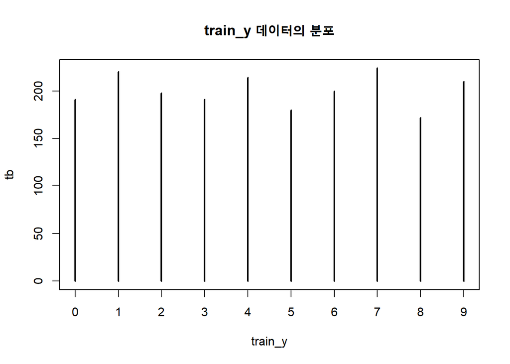

```r
#2000개의 데이터 사용
train_x <- mnist$train$images[1:2000,]
train_y <- mnist$train$labels[1:2000]

#train_y의 분포 확인
tb <- table(train_y)
plot(tb,main="train_y 데이터의 분포")
```

**-결과해석**  
train 데이터의 값 분포가 대체로 고르다고 볼 수 있다. 결과를 도출하는데 무리가 있을 정도의 큰 차이는 보이지 않는다.

#### C) train_x의 column의 이름을 V1, V2, V3 … 순서대로 설정하자. colnames() 함수를 사용하여 column의 이름을수정할 수 있다.

```r
#colum 개수
n<-ncol(train_x)
n
```

```
## [1] 784
```

```r
# for문
X <-c()
for (col in 1:n){
  X[col]<-paste("V",col,sep="")
}


#column 이름 설정
colnames(train_x)<-X[1:n]
head(colnames(train_x))
```

```
## [1] "V1" "V2" "V3" "V4" "V5" "V6"
```

#### D) 784개의 픽셀 중에서 숫자와 관련없는 가장자리 부분과 같은 경우는 많은 데이터들에 대해서 같은 색을 가진다. 이러한 픽셀은 숫자를 분류하는 데 크게 영향을 미치지 않으므로 feature에서 제외시키는 것이 합리적이다. caret 패키지의 nearZeroVar(train_x) 함수를 실행하면 train_x의 column들 중에서 variance가 0이거나 0에 가까운 것들의 index를 얻을 수 있다. 이 index에 해당하는 column을 train_x에서 제외시키자. 784개의 feature 중에서 몇개가 제외되었는가

```r
#variance 0에 가까운 index
nz <-nearZeroVar(train_x)
nz
```

```
##   [1]   1   2   3   4   5   6   7   8   9  10  11  12  13  14  15  16  17  18
##  [19]  19  20  21  22  23  24  25  26  27  28  29  30  31  32  33  34  35  36
##  [37]  37  38  39  40  41  42  43  44  45  46  47  48  49  50  51  52  53  54
##  [55]  55  56  57  58  59  60  61  62  63  64  65  66  67  68  69  70  71  72
##  [73]  73  74  75  76  77  78  79  80  81  82  83  84  85  86  87  88  89  90
##  [91]  91  92  93  94  95  96  97  98  99 100 101 102 103 104 105 106 107 108
## [109] 109 110 111 112 113 114 115 116 117 118 119 120 121 122 123 124 125 126
## [127] 127 128 129 130 131 132 133 134 135 136 137 138 139 140 141 142 143 144
## [145] 145 146 147 148 149 150 151 152 153 161 162 163 164 165 166 167 168 169
## [163] 170 171 172 173 174 175 176 177 178 191 192 193 194 195 196 197 198 199
## [181] 200 201 202 203 204 205 219 220 221 222 223 224 225 226 227 228 229 230
## [199] 231 232 233 247 248 249 250 251 252 253 254 255 256 257 258 259 260 275
## [217] 276 277 278 279 280 281 282 283 284 285 286 287 288 303 304 305 306 307
## [235] 308 309 310 311 312 313 314 315 316 331 332 333 334 335 336 337 338 339
## [253] 340 341 342 343 344 358 359 360 361 362 363 364 365 366 367 368 369 370
## [271] 371 372 386 387 388 389 390 391 392 393 394 395 396 397 398 399 414 415
## [289] 416 417 418 419 420 421 422 423 424 425 426 427 442 443 444 445 446 447
## [307] 448 449 450 451 452 453 454 455 470 471 472 473 474 475 476 477 478 479
## [325] 480 481 482 483 498 499 500 501 502 503 504 505 506 507 508 509 510 511
## [343] 526 527 528 529 530 531 532 533 534 535 536 537 538 554 555 556 557 558
## [361] 559 560 561 562 563 564 565 566 567 581 582 583 584 585 586 587 588 589
## [379] 590 591 592 593 594 595 608 609 610 611 612 613 614 615 616 617 618 619
## [397] 620 621 622 623 624 635 636 637 638 639 640 641 642 643 644 645 646 647
## [415] 648 649 650 651 652 662 663 664 665 666 667 668 669 670 671 672 673 674
## [433] 675 676 677 678 679 680 681 682 683 684 687 688 689 690 691 692 693 694
## [451] 695 696 697 698 699 700 701 702 703 704 705 706 707 708 709 710 711 712
## [469] 713 714 715 716 717 718 719 720 721 722 723 724 725 726 727 728 729 730
## [487] 731 732 733 734 735 736 737 738 739 740 741 742 743 744 745 746 747 748
## [505] 749 750 751 752 753 754 755 756 757 758 759 760 761 762 763 764 765 766
## [523] 767 768 769 770 771 772 773 774 775 776 777 778 779 780 781 782 783 784
```

```r
#column 제거
train_x <- train_x[,-nearZeroVar(train_x)]
ncol(train_x)
```

```
## [1] 244
```

**–결과해석**  
제거된 후 남은 feature의 개수는 244개이므로 제거된 feature는 총 540개이다.

#### E) 최종적으로 train_x와 train_y를 합쳐서 train이라는 이름의 데이터프레임을 만들자.

```r
train <- data.frame(train_x,train_y)
str(train)
```

```
## 'data.frame':    2000 obs. of  245 variables:
##  $ V154   : int  18 0 0 0 0 0 253 105 63 0 ...
##  $ V155   : int  18 48 0 0 0 0 252 255 197 0 ...
##  $ V156   : int  18 238 0 0 0 13 71 253 0 0 ...
##  $ V157   : int  126 252 0 0 0 25 0 253 0 0 ...
##  $ V158   : int  136 252 0 0 0 100 0 253 0 0 ...
##  $ V159   : int  175 252 0 124 0 122 0 253 0 0 ...
##  $ V160   : int  26 237 0 253 0 7 0 253 0 0 ...
##  $ V179   : int  94 0 0 0 0 0 0 139 0 0 ...
##  $ V180   : int  154 0 0 0 0 0 11 224 0 0 ...
##  $ V181   : int  170 0 0 0 0 0 175 226 20 0 ...
##  $ V182   : int  253 54 0 0 0 33 253 252 254 0 ...
##  $ V183   : int  253 227 0 0 0 151 252 253 230 0 ...
##  $ V184   : int  253 253 0 0 0 208 71 252 24 0 ...
##  $ V185   : int  253 252 0 0 0 252 0 252 0 0 ...
```

[output cut: 86 more lines]

#### F) C~E의 과정을 test set에 대해서 동일하게 수행하여 test라는 이름의 데이터프레임을 만들자. 이때 D에서 제외한feature와 동일한 feature들을 test set에서도 제외시켜야 한다.

```r
#data
test_x <- mnist$test$images
test_y <- mnist$test$labels

#colum 개수
m<-ncol(test_x)
m
```

```
## [1] 784
```

```r
# for문
Y<-c()
for (col in 1:m){
  Y[col]<-paste("V",col,sep="")
}

#column 이름 설정
colnames(test_x)<-Y[1:m]
head(colnames(test_x))
```

```
## [1] "V1" "V2" "V3" "V4" "V5" "V6"
```

```r
#column 제거
test_x <- test_x[,-nz]
ncol(test_x)
```

```
## [1] 244
```

```r
#data frame 생성
test <- data.frame(test_x,test_y)
str(test)
```

```
## 'data.frame':    10000 obs. of  245 variables:
##  $ V154  : int  0 142 0 251 0 0 0 0 0 0 ...
##  $ V155  : int  0 176 0 251 0 0 0 0 0 0 ...
##  $ V156  : int  0 253 0 253 0 0 0 0 75 0 ...
##  $ V157  : int  0 253 87 107 0 77 0 0 153 0 ...
##  $ V158  : int  0 122 252 0 0 254 0 0 217 0 ...
##  $ V159  : int  0 0 82 0 0 107 0 0 253 0 ...
##  $ V160  : int  0 0 0 0 70 3 0 0 253 0 ...
##  $ V179  : int  0 210 0 0 121 0 250 0 0 0 ...
##  $ V180  : int  0 32 0 21 231 0 169 14 0 0 ...
##  $ V181  : int  0 12 0 197 0 0 0 149 35 0 ...
##  $ V182  : int  0 0 0 251 0 0 0 193 142 0 ...
##  $ V183  : int  0 6 0 251 0 0 0 5 244 0 ...
##  $ V184  : int  0 206 0 253 0 19 0 0 252 0 ...
##  $ V185  : int  0 253 135 107 0 227 0 0 253 0 ...
```

[output cut: 86 more lines]

#### 2.아래의 코드는 test set의 첫번째 데이터를 화면에 이미지로 출력해준다. 이를 활용하여 test set의 image 행렬의 행 번호를 입력받아 숫자 이미지를 출력하는 함수 print_image()를 만들어보자. 이 함수를 활용하여test set 중에서 이미지로부터 실제 숫자값을 유추하기 어려운 예를 몇 개 찾아보자

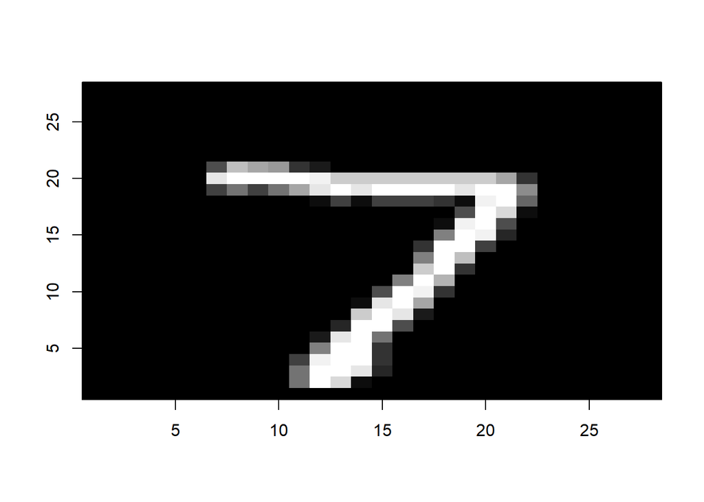

```r
image(1:28,1:28,matrix(mnist$test$images[1,],nrow=28)[,28:1],col=gray(seq(0,1,0.05)),xlab="",ylab="")
```

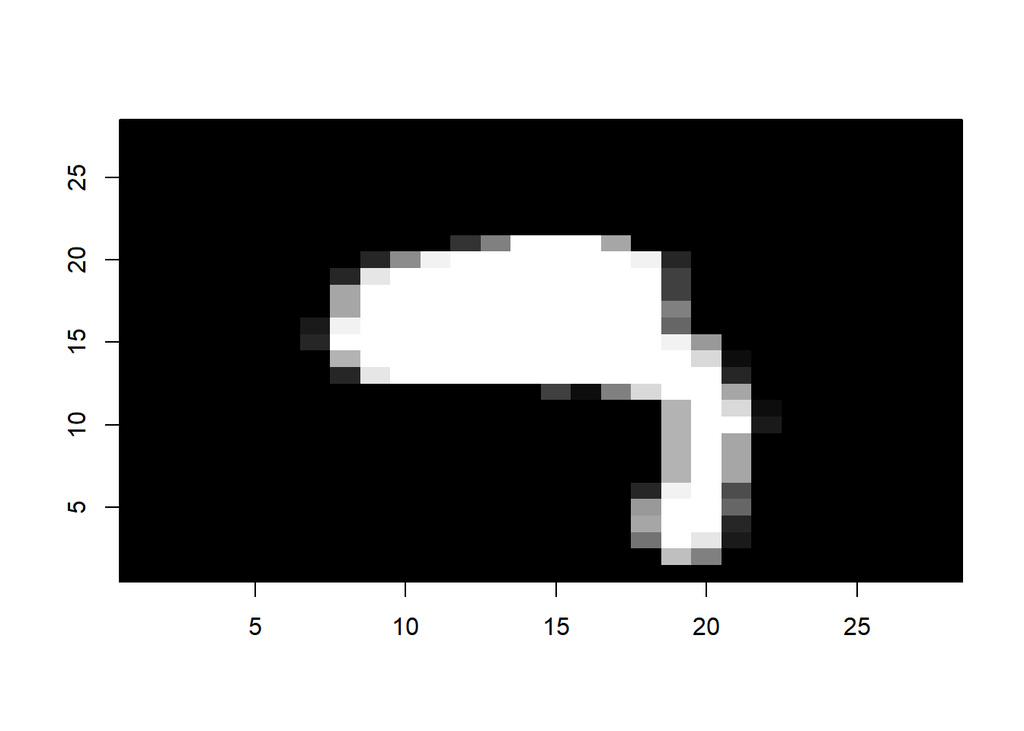

```r
print_image <-function(x){
  image(1:28,1:28,matrix(mnist$test$images[x,],nrow=28)[,28:1],col=gray(seq(0,1,0.05)),xlab="",ylab="")
}

# 숫자값 유추하기 어려운 몇가지 예
print_image(210)
```

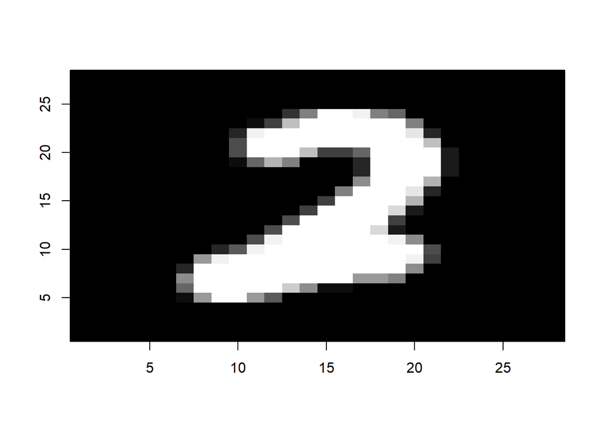

```r
print_image(200)
```

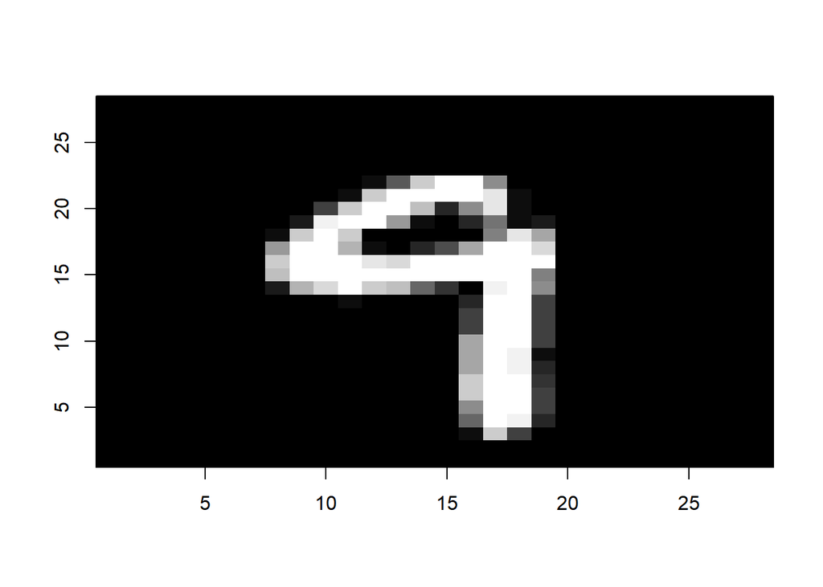

```r
print_image(109)
```

**–결과해석**  
210번째 이미지는 7인지 9인지 형태가 모호해서 구분할 수가 없다. 200번째 이미지는 2인지 7인지 정확하게 판단하기 어렵다. 109번째 이미지는 4인지 9인지 형태만으로는 판단하기 어렵다.

#### 3. 아래의 순서로 tree를 만들어보자.

#### A) Cost complexity parameter alpha = 0 일때, leaf node가 가지는 최소 데이터의 수가 50인 Tree를 만들고 시각화해보자. Tree는 몇 개의 leaf node를 가지는가? Tree의 depth는 얼마인가?

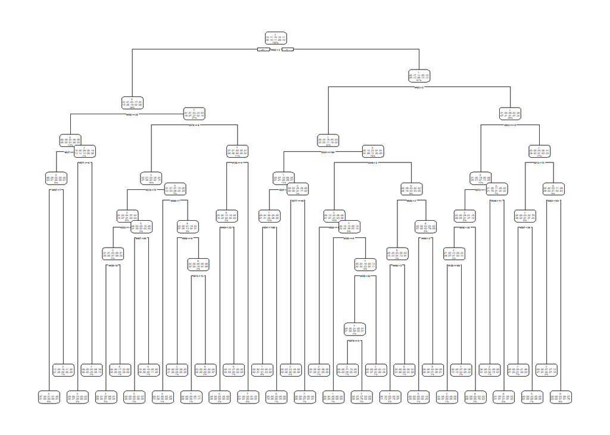

```r
set.seed(123)
ctA <- rpart(train_y~.,data=train,method="class",minsplit=50,control = list(cp=0))

#시각화
rpart.plot(ctA)
```

#### B) Cost complexity parameter alpha=0 일때, depth가 최대 3인 Tree를 만들고 시각화해보자. Tree는 몇개의leaf node를 가지는가? 만들어진 tree가 실제 classification에 활용될 수 있을까?

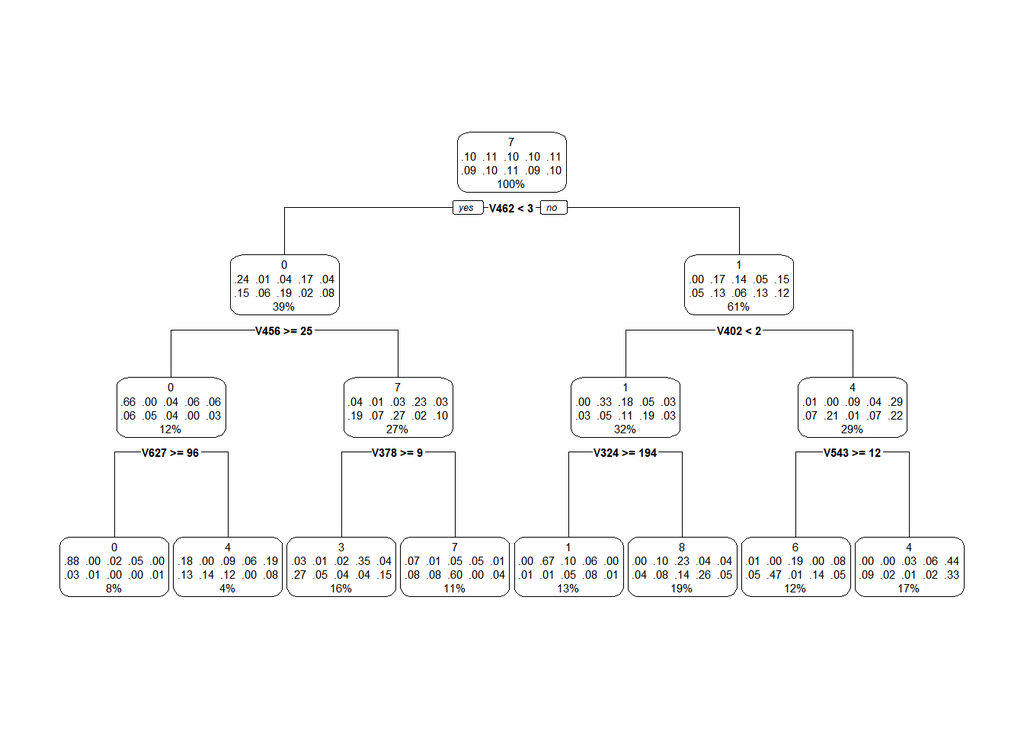

```r
set.seed(123)
ctB <- rpart(train_y~.,data=train, method="class",maxdepth=3,control = list(cp=0))

#시각화
rpart.plot(ctB)
```

**–결과 해석–**  
실제 classification에 활용할 수 없을 것이라 생각한다. 왜냐하면 leaf node에 숫자 9로 분류한 값이 없기 때문이다.

#### C) rpart() 함수를 사용하여 Tree를 만든 후 cross validation을 활용한 pruning 과정을 수행해보자.

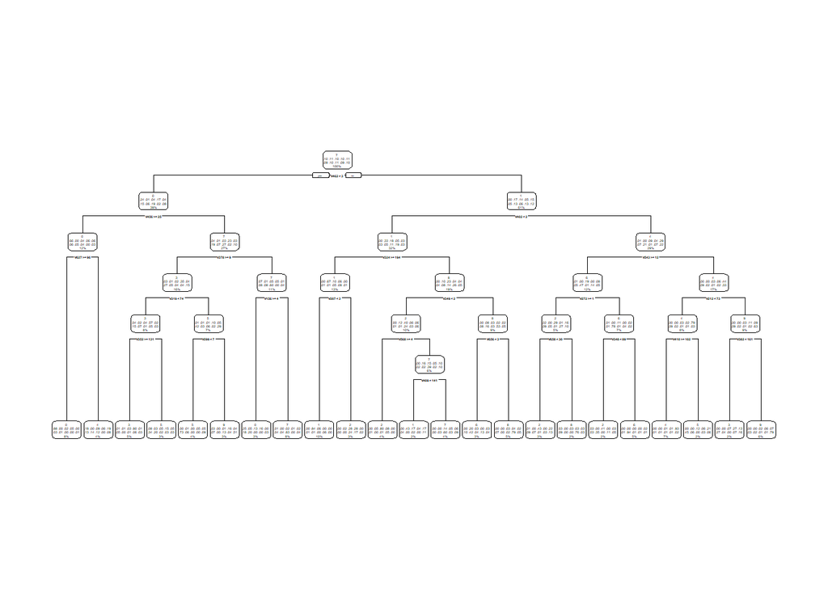

```r
# Tree 만들기
set.seed(123)
ctC <- rpart(train_y~.,data=train, method="class",minsplit=100,control = list(cp=0))
rpart.plot(ctC)
```

```r
#cross validation의 결과 출력
printcp(ctC)
```

```
##
## Classification tree:
## rpart(formula = train_y ~ ., data = train, method = "class",
##     control = list(cp = 0), minsplit = 100)
##
## Variables actually used in tree construction:
##  [1] V156 V207 V212 V272 V299 V319 V324 V348 V349 V352 V378 V382 V402 V409 V410
## [16] V456 V462 V543 V568 V627 V656 V658
##
## Root node error: 1776/2000 = 0.888
##
## n= 2000
##
##            CP nsplit rel error  xerror      xstd
## 1  0.09909910      0   1.00000 1.01239 0.0075877
## 2  0.09403153      1   0.90090 0.96903 0.0087244
## 3  0.06700450      2   0.80687 0.80912 0.0113246
## 4  0.05630631      3   0.73986 0.70721 0.0121709
## 5  0.05236486      4   0.68356 0.66385 0.0123871
## 6  0.05180180      5   0.63119 0.63908 0.0124752
## 7  0.03856982      6   0.57939 0.58559 0.0125804
## 8  0.02590090      8   0.50225 0.53378 0.0125734
## 9  0.01689189      9   0.47635 0.49718 0.0125040
## 10 0.01632883     10   0.45946 0.47185 0.0124242
## 11 0.01407658     11   0.44313 0.46509 0.0123984
## 12 0.01126126     13   0.41498 0.45045 0.0123361
## 13 0.01069820     14   0.40372 0.44820 0.0123257
## 14 0.00844595     15   0.39302 0.43300 0.0122499
## 15 0.00788288     16   0.38457 0.43018 0.0122348
## 16 0.00619369     17   0.37669 0.42793 0.0122225
## 17 0.00450450     18   0.37050 0.42173 0.0121874
## 18 0.00281532     19   0.36599 0.41892 0.0121709
## 19 0.00112613     20   0.36318 0.41667 0.0121575
## 20 0.00056306     21   0.36205 0.41667 0.0121575
## 21 0.00000000     22   0.36149 0.41892 0.0121709
```

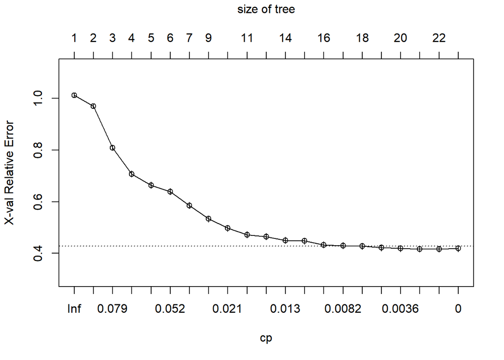

```r
#cross validation의 결과 시각화
plotcp(ctC)
```

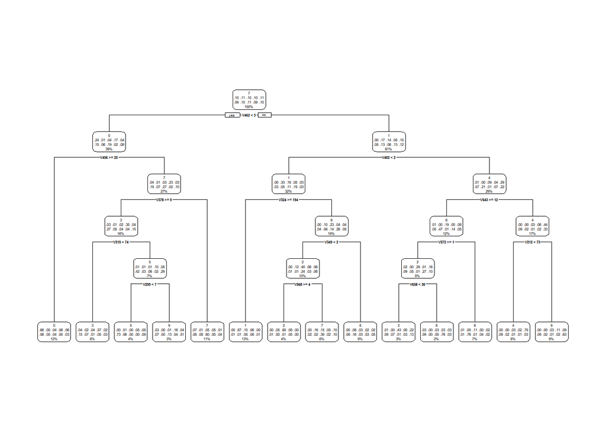

```r
#best cp 값일 때의 pruned tree 생성
best_ct <- prune(ctA,cp=0.013)

# pruning 결과 시각화
rpart.plot(best_ct)
```

**–결과해석**  
tree를 최대한 단순하게 만들기 위해 pruning 후 rpart.plot한 그래프에서 점선에 가깝게 위치한 값중 알파값이 최대가 되도록 임의로 cp값을 설정해 주었다.그결과 tree의 maxdepth는 5로 leaf node의 개수는 14개로 tree가 단순화 되었다.

#### D) C에서 얻은 tree로 test set에 대한 예측을 수행하고, confusion matrix를 계산해보자. Test set에 대한 예측정확도는 얼마인가?

```r
#test set에 대한 예측 오차 계산
pred_class <- predict(best_ct,newdata=test,type="class")
confusionMatrix(factor(pred_class),factor(test$test_y))
```

```
## Confusion Matrix and Statistics
##
##           Reference
## Prediction   0   1   2   3   4   5   6   7   8   9
##          0 760   0  43  38  45  54 113  30  20  40
##          1   0 856 181  90   5  15   7  54 143  17
##          2   5  28 454  17  46  33  52  32  21  25
##          3  20  11  24 466  30 110  42   4  33  51
##          4   1   0  19  18 531  64  29  15  23  61
##          5   6   2   1  61  12 269  18   3  11  37
##          6   0   0  30   8  31  23 497   2  30  10
##          7 158 136 237 111  91  82 108 845  23 110
##          8  13 101  24  39  34  83  80  16 588  40
##          9  17   1  19 162 157 159  12  27  82 618
##
## Overall Statistics
##
##                Accuracy : 0.5884
##                  95% CI : (0.5787, 0.5981)
##     No Information Rate : 0.1135
##     P-Value [Acc > NIR] : < 2.2e-16
##
##                   Kappa : 0.5419
##
##  Mcnemar's Test P-Value : NA
##
## Statistics by Class:
##
##                      Class: 0 Class: 1 Class: 2 Class: 3 Class: 4 Class: 5
## Sensitivity            0.7755   0.7542   0.4399   0.4614   0.5407   0.3016
## Specificity            0.9575   0.9422   0.9711   0.9638   0.9745   0.9834
## Pos Pred Value         0.6649   0.6257   0.6367   0.5891   0.6978   0.6405
## Neg Pred Value         0.9752   0.9677   0.9378   0.9409   0.9512   0.9350
## Prevalence             0.0980   0.1135   0.1032   0.1010   0.0982   0.0892
## Detection Rate         0.0760   0.0856   0.0454   0.0466   0.0531   0.0269
## Detection Prevalence   0.1143   0.1368   0.0713   0.0791   0.0761   0.0420
## Balanced Accuracy      0.8665   0.8482   0.7055   0.7126   0.7576   0.6425
##                      Class: 6 Class: 7 Class: 8 Class: 9
## Sensitivity            0.5188   0.8220   0.6037   0.6125
## Specificity            0.9852   0.8823   0.9524   0.9293
## Pos Pred Value         0.7876   0.4445   0.5776   0.4928
## Neg Pred Value         0.9508   0.9774   0.9570   0.9553
## Prevalence             0.0958   0.1028   0.0974   0.1009
## Detection Rate         0.0497   0.0845   0.0588   0.0618
## Detection Prevalence   0.0631   0.1901   0.1018   0.1254
## Balanced Accuracy      0.7520   0.8521   0.7780   0.7709
```

**–결과 해석**  
test set에 대한 예측 정확도는 0.5884로 정확도가 높지 않다.

#### 4.Random Forest를 만들어보자.

#### A) randomForest() 함수를 사용하여 bagging model을 만들어보자. mtry를 제외한 옵션은 모두 default 값을사용한다. plot() 함수를 사용하여 Bagging model에서 tree의 수의 증가에 따른 OOB classification error rate의 변화를 그래프로 출력해보자. 어떤 경향을 보이는가?

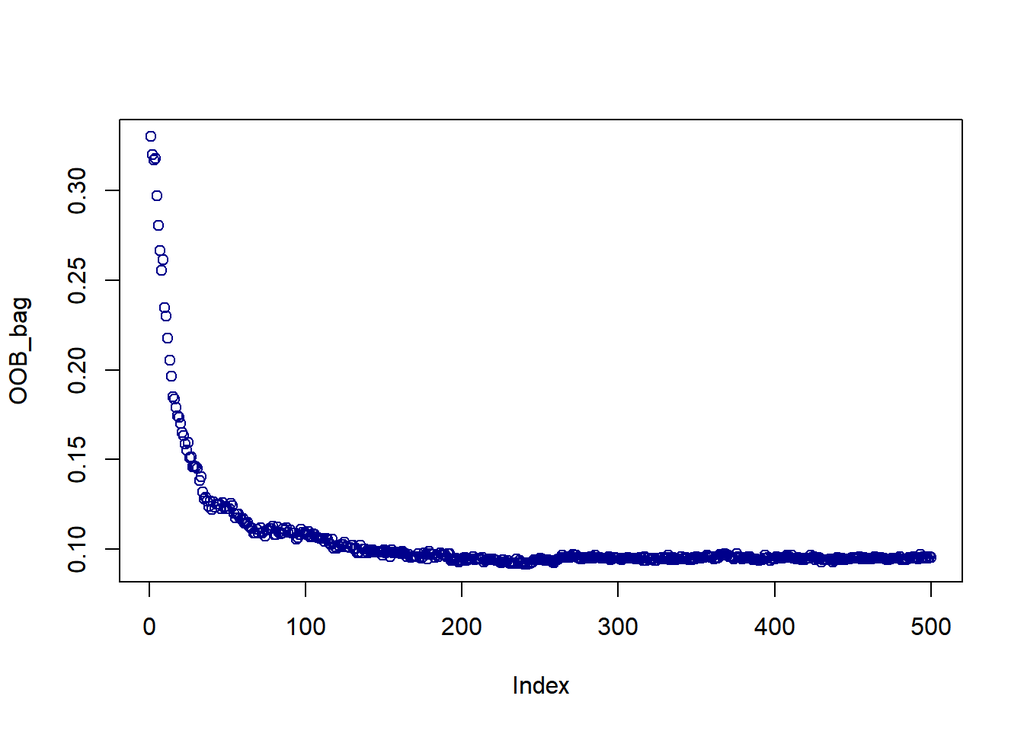

```r
train$train_y <- factor(train_y)
test$test_y <- factor(test$test_y)

#training set에 bagging 적용
set.seed(123)
bag <- randomForest(train_y~.,data=train,mtry=244)

#tree 개수에 따른 bagging model의 out-of-bag MSE 계산
OOB_bag <-bag$err.rate[,"OOB"]
plot(OOB_bag,col="darkblue")
```

**–결과해석**  
알아보기 슆도록 전체 OOB error rate의 그래프만 그려주었다. 그 결과 tree의 수가 증가할 수록 OOB error rate가 감소한다는 것을 알 수 있다. 그러나 tree의 개수가 200개 이상부터는 OOB error rate의 유의미한 차이가 없다.

#### B) Bagging model로 test set에 대한 예측을 수행하고, confusion matrix를 계산해보자. Test set에 대한 예측정확도는 얼마인가? 3번에서 계산한 tree model에 비해서 성능이 얼마나 향상되었는가?

```r
#confustion Matrix 작성
pred_bag <- predict(bag,newdata=test,type="class")
confusionMatrix(pred_bag,test$test_y)
```

```
## Confusion Matrix and Statistics
##
##           Reference
## Prediction    0    1    2    3    4    5    6    7    8    9
##          0  940    0    9    4    1   17   21    0    7    5
##          1    0 1107    3    0    2    8    3    7    7    4
##          2    0    7  929   27    4    1   24   33   15   10
##          3    3    6    8  832    2   16    0    6   23   15
##          4    3    0   14    2  866   10   25    3   13   27
##          5   10    1   10   84    2  800   17    1   26   16
##          6    9    3   16    5   19   10  858    0   27    8
##          7   11    1   26   28    1   11    2  922    5   12
##          8    2   10   11   17   12   11    7    4  802    3
##          9    2    0    6   11   73    8    1   52   49  909
##
## Overall Statistics
##
##                Accuracy : 0.8965
##                  95% CI : (0.8904, 0.9024)
##     No Information Rate : 0.1135
##     P-Value [Acc > NIR] : < 2.2e-16
##
##                   Kappa : 0.885
##
##  Mcnemar's Test P-Value : NA
##
## Statistics by Class:
##
##                      Class: 0 Class: 1 Class: 2 Class: 3 Class: 4 Class: 5
## Sensitivity            0.9592   0.9753   0.9002   0.8238   0.8819   0.8969
## Specificity            0.9929   0.9962   0.9865   0.9912   0.9892   0.9817
## Pos Pred Value         0.9363   0.9702   0.8848   0.9133   0.8993   0.8273
## Neg Pred Value         0.9956   0.9968   0.9885   0.9804   0.9872   0.9898
## Prevalence             0.0980   0.1135   0.1032   0.1010   0.0982   0.0892
## Detection Rate         0.0940   0.1107   0.0929   0.0832   0.0866   0.0800
## Detection Prevalence   0.1004   0.1141   0.1050   0.0911   0.0963   0.0967
## Balanced Accuracy      0.9760   0.9857   0.9434   0.9075   0.9356   0.9393
##                      Class: 6 Class: 7 Class: 8 Class: 9
## Sensitivity            0.8956   0.8969   0.8234   0.9009
## Specificity            0.9893   0.9892   0.9915   0.9775
## Pos Pred Value         0.8984   0.9048   0.9124   0.8182
## Neg Pred Value         0.9889   0.9882   0.9811   0.9888
## Prevalence             0.0958   0.1028   0.0974   0.1009
## Detection Rate         0.0858   0.0922   0.0802   0.0909
## Detection Prevalence   0.0955   0.1019   0.0879   0.1111
## Balanced Accuracy      0.9424   0.9430   0.9074   0.9392
```

**–결과해석**  
bagging 했을 때의 accuracy는 0.8965로 앞선 3번의 decision tree모델의 accuracy(0.5884)보다 눈에 띄게 정확도가 상승하였다.

#### C) randomForest() 함수의 default 옵션을 사용하여 random forest model을 만들어보자. 그리고 Bagging과random forest 모델의 Tree의 수의 증가에 따른 OOB classification error rate의 변화를 하나의 그래프에그려보고 두 모델의 성능을 비교해보자.

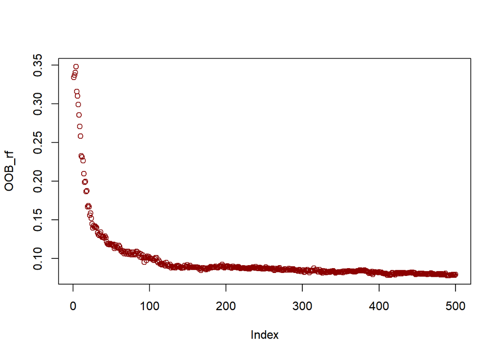

```r
#random forest 생성
set.seed(123)
rf_class <- randomForest(train_y~.,data=train)

#plot
OOB_rf<-rf_class$err.rate[,"OOB"]
plot(OOB_rf,col="darkred")
```

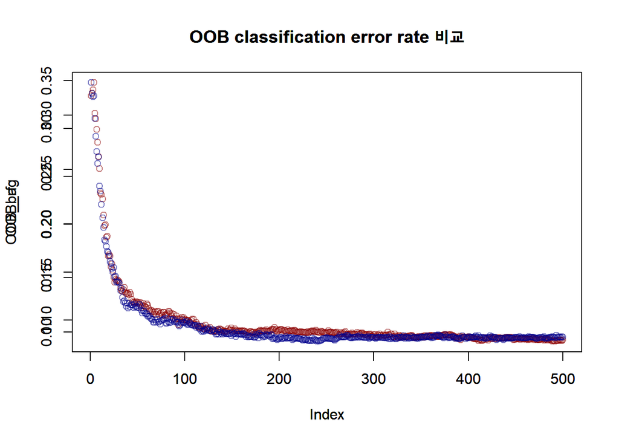

```r
# 두 그래프 비교
plot(OOB_rf,col=adjustcolor("darkred",alpha=0.5),main="OOB classification error rate 비교")
par(new=TRUE)
plot(OOB_bag,col=adjustcolor("darkblue",alpha=0.5),main="OOB classification error rate 비교")
```

#### D) Random forest model로 test set에 대한 예측을 수행하고, confusion matrix를 계산해보자. Test set에대한 예측 정확도는 얼마인가? Bagging model에 비해서 성능이 얼마나 향상되었는가?

```r
pred_rf <- predict(rf_class,newdata=test,type="class")
cf<-confusionMatrix(pred_rf,test$test_y)
cf
```

```
## Confusion Matrix and Statistics
##
##           Reference
## Prediction    0    1    2    3    4    5    6    7    8    9
##          0  954    0   10    2    1   16   19    0    9    8
##          1    0 1113    1    0    1   10    3   12    3    5
##          2    3    3  949   24    4    1   22   36    8    7
##          3    0    3    7  882    0   20    0    0   19   15
##          4    5    0   14    2  895   10   16    4   12   20
##          5    7    3    6   57    0  790   12    1   19    9
##          6    7    4   15    5   15   14  882    1   22    5
##          7    3    1   17   18    0    9    1  924    9   10
##          8    1    8   11   12    5    6    3    4  833    4
##          9    0    0    2    8   61   16    0   46   40  926
##
## Overall Statistics
##
##                Accuracy : 0.9148
##                  95% CI : (0.9092, 0.9202)
##     No Information Rate : 0.1135
##     P-Value [Acc > NIR] : < 2.2e-16
##
##                   Kappa : 0.9053
##
##  Mcnemar's Test P-Value : NA
##
## Statistics by Class:
##
##                      Class: 0 Class: 1 Class: 2 Class: 3 Class: 4 Class: 5
## Sensitivity            0.9735   0.9806   0.9196   0.8733   0.9114   0.8857
## Specificity            0.9928   0.9961   0.9880   0.9929   0.9908   0.9875
## Pos Pred Value         0.9362   0.9695   0.8978   0.9323   0.9151   0.8739
## Neg Pred Value         0.9971   0.9975   0.9907   0.9859   0.9904   0.9888
## Prevalence             0.0980   0.1135   0.1032   0.1010   0.0982   0.0892
## Detection Rate         0.0954   0.1113   0.0949   0.0882   0.0895   0.0790
## Detection Prevalence   0.1019   0.1148   0.1057   0.0946   0.0978   0.0904
## Balanced Accuracy      0.9831   0.9883   0.9538   0.9331   0.9511   0.9366
##                      Class: 6 Class: 7 Class: 8 Class: 9
## Sensitivity            0.9207   0.8988   0.8552   0.9177
## Specificity            0.9903   0.9924   0.9940   0.9808
## Pos Pred Value         0.9093   0.9315   0.9391   0.8426
## Neg Pred Value         0.9916   0.9885   0.9845   0.9907
## Prevalence             0.0958   0.1028   0.0974   0.1009
## Detection Rate         0.0882   0.0924   0.0833   0.0926
## Detection Prevalence   0.0970   0.0992   0.0887   0.1099
## Balanced Accuracy      0.9555   0.9456   0.9246   0.9492
```

**–결과해석**  
Random forest model로 test set에 대한 예측을 수행했을 때 accuracy가 0.9148이 출력되었다. 이는 bagging model의 accuracy 0.8965에 비해 정확도가 상승했다는 것을 알 수 있다.

#### F) 실제 값은 7이지만 Random forest model에 의해 1로 예측되는 test data를 찾아 이미지를 몇 개 출력해보자. 눈으로 확인했을 때 7과 1의 구별이 어려운가?

```r
# 실제 값 7인데 1로 예측된 test data 인덱스 추출
test71 <-c()
for (i in 1:10000){
  if(pred_rf[i]==1 && test_y[i]==7){
    test71 = c(test71,i)
  }
}
test71
```

```
##  [1]  552 1261 1501 1717 2064 3226 3581 3839 3977 4298 4887 4967
```

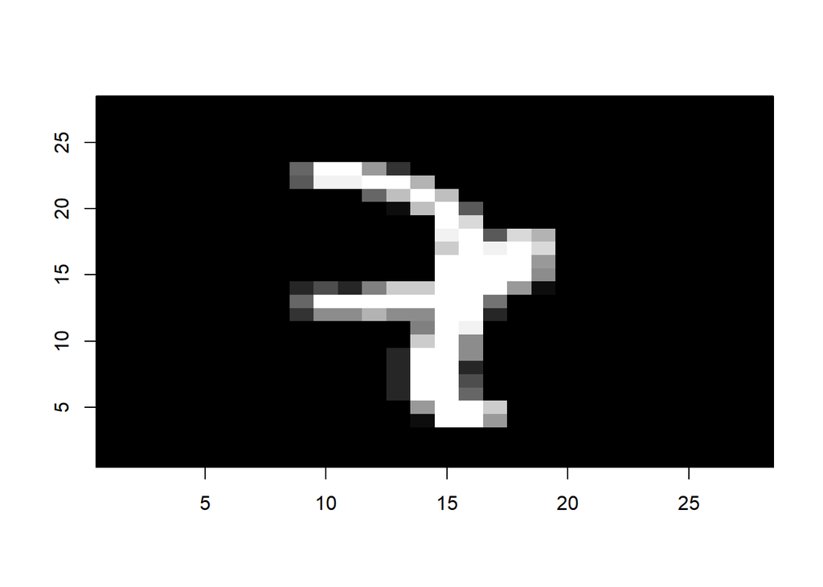

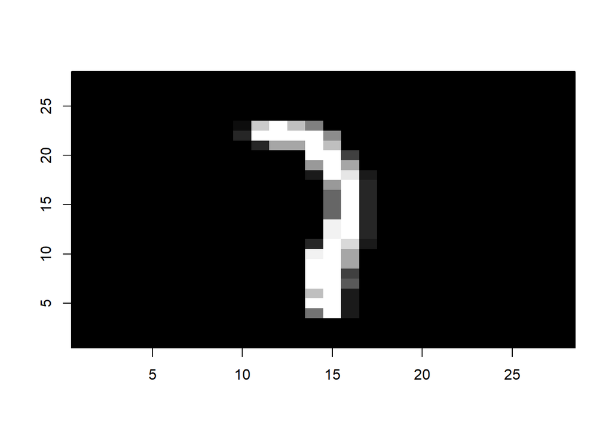

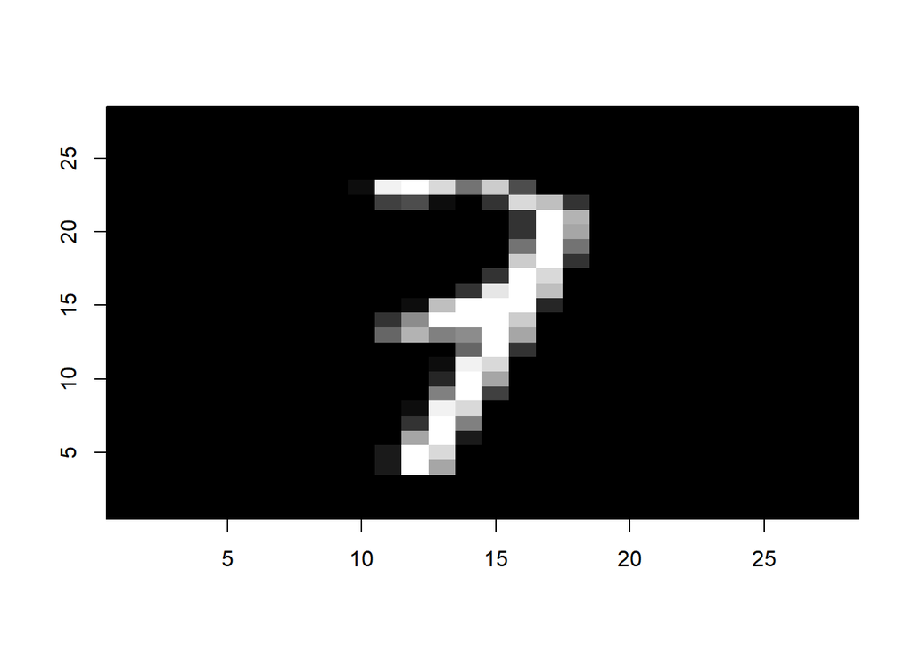

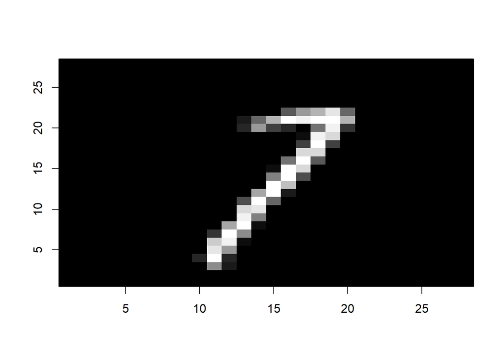

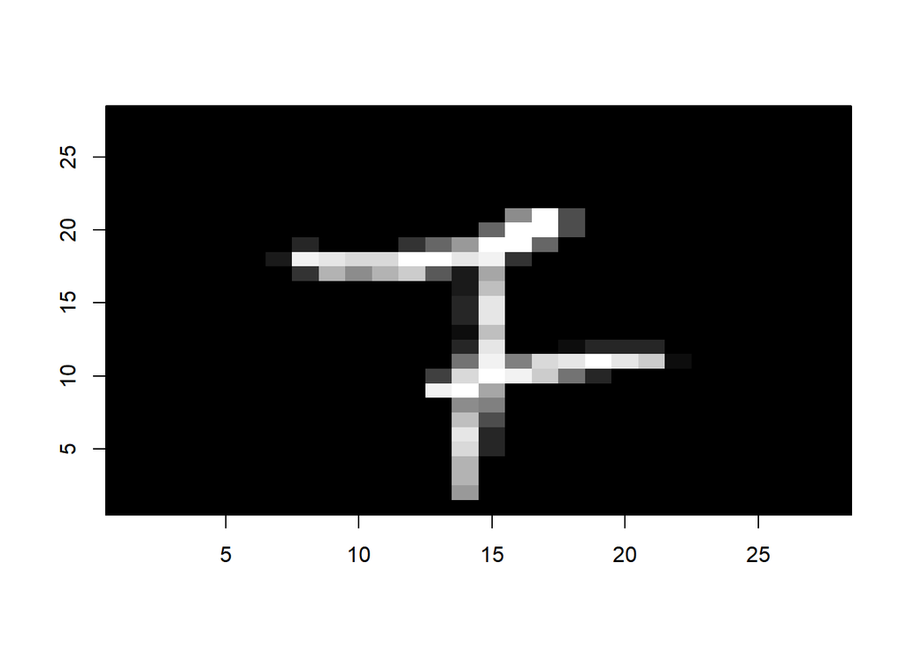

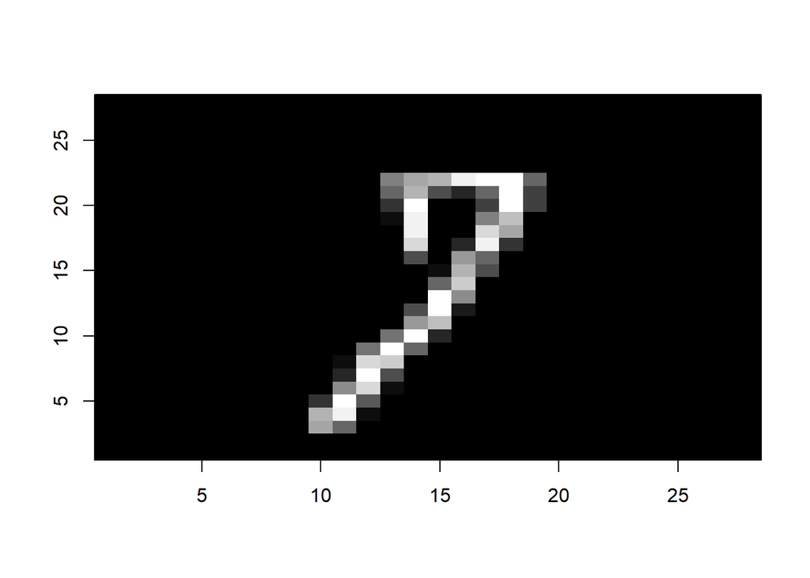

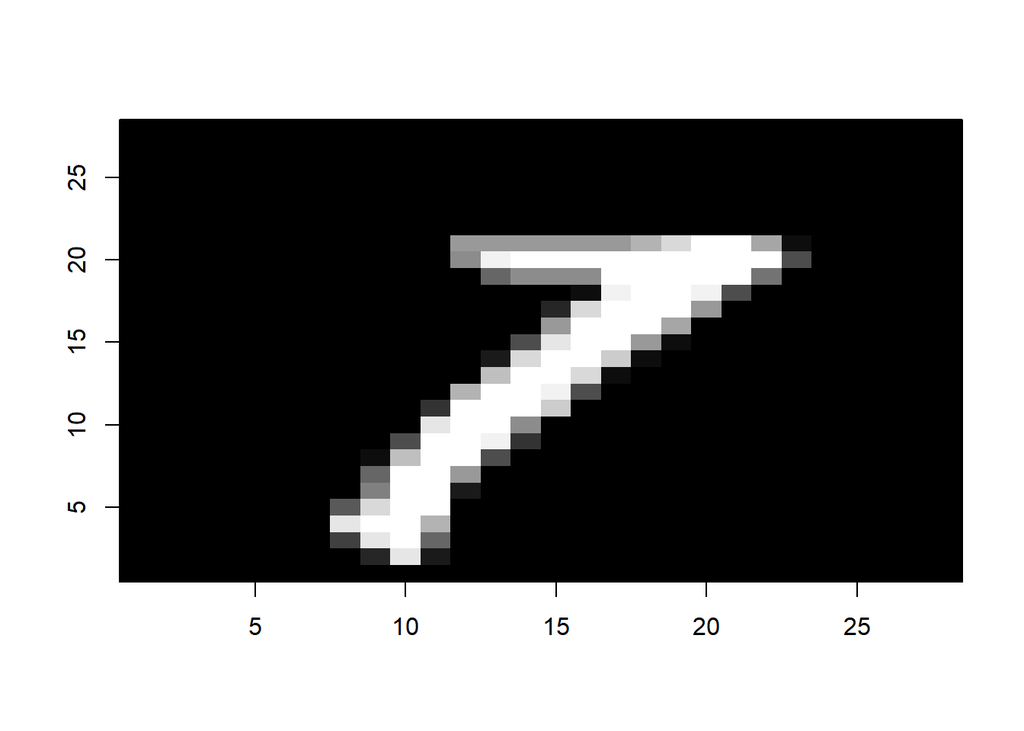

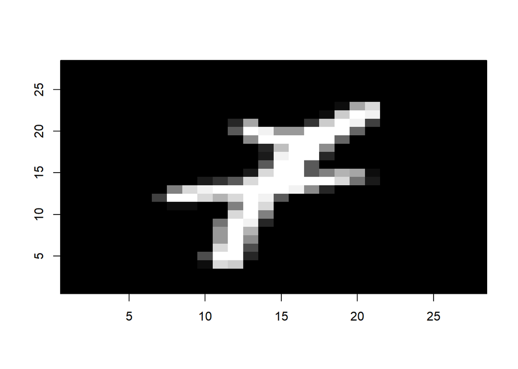

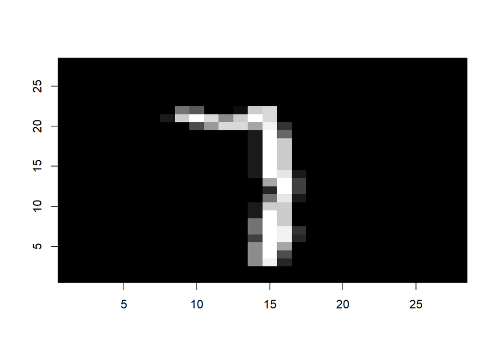

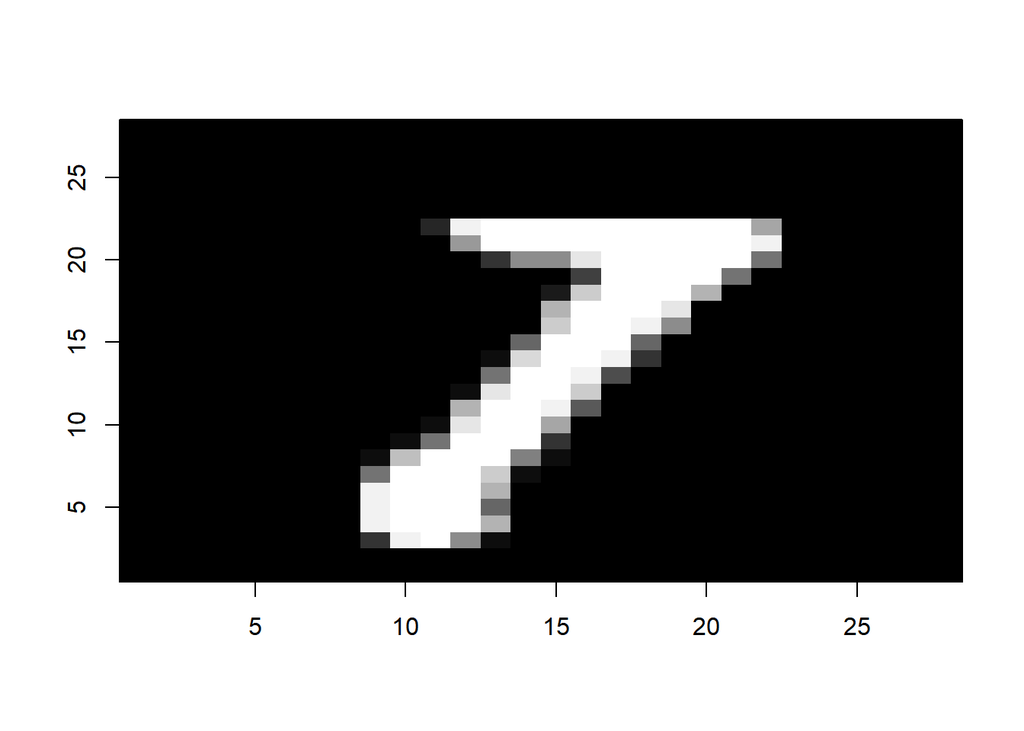

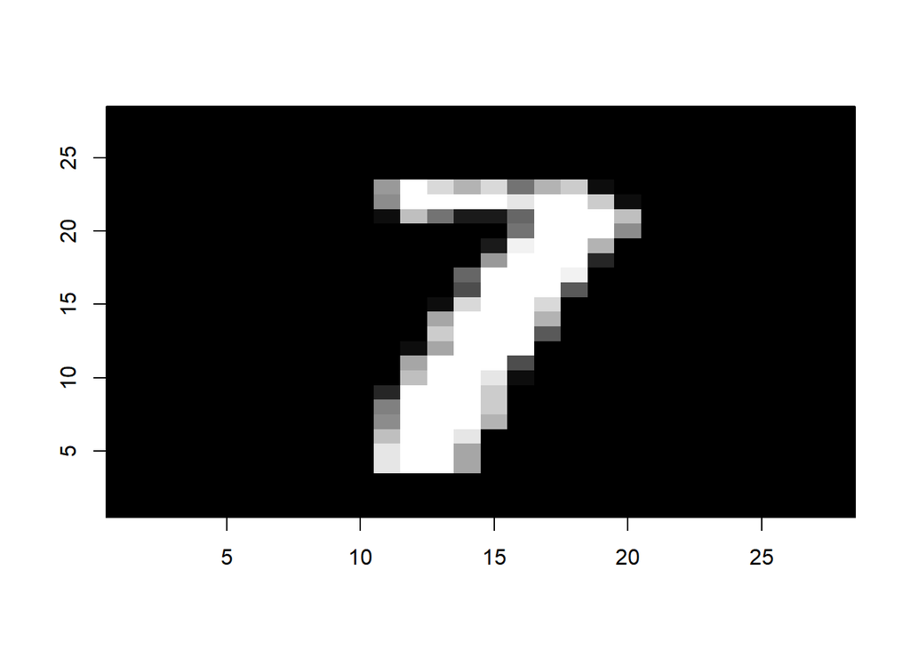

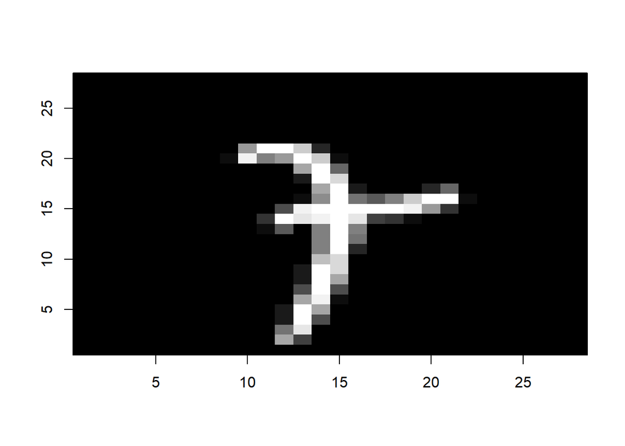

```r
#이미지 출력
for (i in test71){
  print_image(i)
}
```

**–결과 해석**  
이미지 출력 결과 5개 정도의 이미지는 1과 7의 구분이 모호하다.